# Reporte final del pipeline

Trabajo Unidad 2 — Técnicas Avanzadas de Programación  
Generado automáticamente por el Proceso 3 el 19/07/2026 23:12  
Corrida analizada: 2026-07-19T23:12:31 · commit `9b063a0 (árbol limpio)`

El reporte es el resultado propio del Proceso 3. A diferencia de `generaReporteTask` (Proceso 2), que resume solo la búsqueda en Bash, aquí se **integran y comparan** las dos estrategias de búsqueda que conviven en el pipeline.

## 1.Comparacion PySpark vs Bash

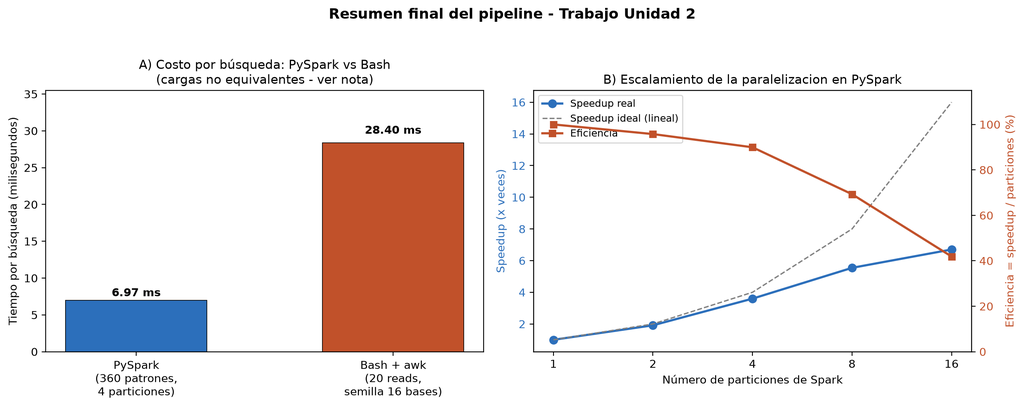

| Metrica | PySpark (Proceso 1) | Bash + awk (Proceso 2) |
| --- | --- | --- |
| Busquedas realizadas | 360 | 20 |
| Tiempo total (s) | 2.51 | 0.57 |
| Tiempo por busqueda (ms) | 6.97 | 28.40 |
| Ocurrencias contadas | todas (solapadas) | solo la primera |
| Paralelismo | 4 particiones | secuencial |
| Reads con calce | — | 4 de 20 |

**Nota.** Las dos herramientas **no ejecutan la misma carga**: PySpark evalua 360 patrones de largo variable y cuenta *todas* las ocurrencias solapadas mediante *lookahead*; Bash busca 20 reads por una semilla de 16 bases y se detiene en la *primera* coincidencia. Comparar tiempos totales seria engañoso, por eso después la comparación se normalizó por búsqueda. Aun así, la lectura correcta es cualitativa, es decir, PySpark resulta **4.1 veces mas rápido por búsqueda** haciendo estrictamente *mas* trabajo en cada una, pero paga un costo fijo de arranque de la JVM y del contexto de Spark que no aparece en esta métrica y que solo se amortiza con volumen. Con 20 busquedas, Bash es la herramienta razonable; con 360 o mas, deja de serlo.

## 2. Escalamiento de la paralelización

| Particiones | Tiempo medio (s) | Desv. est. (s) | Speedup | Eficiencia | Calces totales |
| --- | --- | --- | --- | --- | --- |
| 1 | 9.025 | 0.009 | 1.00x | 100% | 912469 |
| 2 | 4.712 | 0.026 | 1.92x | 96% | 912469 |
| 4 | 2.508 | 0.008 | 3.60x | 90% | 912469 |
| 8 | 1.628 | 0.046 | 5.54x | 69% | 912469 |
| 16 | 1.347 | 0.071 | 6.70x | 42% | 912469 |

El mejor speedup es **6.70x** con 16 particiones, sobre 16 CPUs logicas. La eficiencia cae de 96% con 2 particiones a 42% con 16: Spark no acelera automáticamente, acelera mientras el trabajo por partición supere el costo de coordinarla.

**Prueba de correctitud:** el total de calces es `912469` e **identico** en las 5 configuraciones evaluadas. La paralelizacion cambio el tiempo, no el resultado.

## 3. Clasificación con CNN 1D

| Metrica | Valor |
| --- | --- |
| Linea base (clase mayoritaria) | 0.6780 |
| Accuracy | 0.9520 |
| Precision | 0.9802 |
| Recall | 0.9484 |
| F1 (clase mayoritaria) | 0.9640 |
| Clases distintas predichas | 2 |

El modelo supera la línea base en 27.4 puntos porcentuales y predice las dos clases, lo que descarta el colapso a la clase mayoritaria.

## 4. Entorno de ejecución

| Componente | Version |
| --- | --- |
| Sistema | Linux-6.18.33.1-microsoft-standard-WSL2-x86_64-with-glibc2.43 |
| Python | 3.14.4 |
| Java | 17.0.19 |
| Spark / PySpark | 4.1.2 / 4.1.2 |
| PyTorch | 2.13.0+cpu |
| Semilla | 42 |